# Chapter 2

Describing socio-economic inequalities in access to planned hospital care

Steven Wyatt, The Strategy Unit

12 March 2021

### 1 Introduction

This chapter describes the extent and nature of socio-economic inequalities in access to planned hospital care. The analysis considers trends in rates of activity, differences in activity rates by levels of deprivation, condition and STP/ICS, waiting times and independent sector provision.

### 2 Set-up and preparatory analysis

#### 2.1 Set-up

##### 2.1.1 Load required R packages

Set working directory.

Packages: tidyverse, scales

```r
setwd('Z:/Strategic Analytics/Projects 2020/753 Ineq Planned Care/panelAnalysis/r - IneqPlannedCare/r - IneqPlannedCare')

library(tidyverse)
library(scales)
```

##### 2.1.2 Read in data sets

The first file contains a counts of elective spells (ordinary inpatient and day case), emergency spells, outpatient attendances and population by; - calendar year (2002 to 2019, note 2019 incomplete) - STP and CCG *- index of multiple deprivation decile (IMD2019)* - single year of age (0-89, 90+) - sex

- derived from patient’s LSOA of residence

The second file is similarly structured but with the following differences: - the file does not include data on outpatient attendances - the file contains the ICD10 chapter of the primary diagnosis of the elective or emergency spell.

These files was created from record-level pseudonymised extracts from Hospital Episode Statistics, supplied by NHS Digital (DARS-NIC-05206-L1V6D-v4.6), using Transact SQL. The TSQL scripts can be provided on request.

The third file contains the european standard population by five year age groups (0, 1-4, 5-9 ….. 85-89, 90+). See https://ec.europa.eu/eurostat/documents/3859598/5926869/KS-RA-13-028-EN.PDF/e713fa79-1add-44e8-b23d-5e8fa09b3f8f

```r
IneqSecCareDsrInput <- readRDS(file = 'IneqSecCareDsrInput.RDS')

IneqSecCareIcd10DsrInput <- readRDS(file = 'IneqSecCareIpIcd10ChapDsrInput.RDS')

esr <- data.frame(ageGrp = rep(c('00', '01-04', '05-09', '10-14', '15-19', '20-24', '25-29', '30-34', '35-39', '40-44',
                                  '45-49', '50-54', '55-59', '60-64', '65-69', '70-74', '75-79', '80-84', '85-89', '90plus'), 2),
                  sex = c(rep(1, 20), rep(2, 20)),
                  sPop = rep(c(1000, 4000, 5500, 5500, 5500, 6000, 6000, 6500, 7000, 7000,
                               7000, 7000, 6500, 6000, 5500, 5000, 4000, 2500, 1500, 1000), 2))
```

#### 2.2 Wrangle data

Bring the first two activity files together, filter for years 2005-2018, group ages to match ESR groups and pivot into tidy data format.

Separately, create a dataframe of counts of elective activity by ICD10 chapter and year.

```r
IneqSecCareDsrInput_wkg <- IneqSecCareDsrInput %>%
  filter(yr >= 2005 & yr <= 2018) %>%
  mutate(ageGrp = case_when(age == 0 ~ '00',
                            age <= 4 ~ '01-04',
                            age <= 10 ~ '05-09',
                            age <= 14 ~ '10-14',
                            age <= 19 ~ '15-19',
                            age <= 24 ~ '20-24',
                            age <= 29 ~ '25-29',
                            age <= 34 ~ '30-34',
                            age <= 39 ~ '35-39',
                            age <= 44 ~ '40-44',
                            age <= 49 ~ '45-49',
                            age <= 54 ~ '50-54',
                            age <= 59 ~ '55-59',
                            age <= 64 ~ '60-64',
                            age <= 69 ~ '65-69',
                            age <= 74 ~ '70-74',
                            age <= 79 ~ '75-79',
                            age <= 84 ~ '80-84',
                            age <= 89 ~ '85-89',
                            age == 90 ~ '90plus',
                            TRUE ~ 'check')) %>%
  group_by(yr, STP20CD, CCG20CD, CCG20CDH, imd2019Dec, ageGrp, sex) %>%
  summarise(ipElec = sum(ipElec),
            ipEmer = sum(ipEmer),
            opAll = sum(opAll),
            pop = sum(pop)) %>%
  pivot_longer(cols = 8:10,
               names_to = 'actType',
               values_to = 'act') %>%
  mutate(icd10Chapter = 'all') %>%
  bind_rows(IneqSecCareIcd10DsrInput %>%
              filter(yr >= 2005 & yr <= 2018) %>%
              mutate(ageGrp = case_when(age == 0 ~ '00',
                                        age <= 4 ~ '01-04',
                                        age <= 10 ~ '05-09',
                                        age <= 14 ~ '10-14',
                                        age <= 19 ~ '15-19',
                                        age <= 24 ~ '20-24',
                                        age <= 29 ~ '25-29',
                                        age <= 34 ~ '30-34',
                                        age <= 39 ~ '35-39',
                                        age <= 44 ~ '40-44',
                                        age <= 49 ~ '45-49',
                                        age <= 54 ~ '50-54',
                                        age <= 59 ~ '55-59',
                                        age <= 64 ~ '60-64',
                                        age <= 69 ~ '65-69',
                                        age <= 74 ~ '70-74',
                                        age <= 79 ~ '75-79',
                                        age <= 84 ~ '80-84',
                                        age <= 89 ~ '85-89',
                                        age == 90 ~ '90plus',
                                        TRUE ~ 'check')) %>%
              group_by(yr, STP20CD, CCG20CD, CCG20CDH, icd10Chapter, imd2019Dec, ageGrp, sex) %>%
              summarise(ipElec = sum(ipElec),
                        ipEmer = sum(ipEmer),
                        pop = sum(pop)) %>%
              pivot_longer(cols = 9:10,
                           names_to = 'actType',
                           values_to = 'act'))

ipElecActIcd10Yr <- IneqSecCareIcd10DsrInput %>%
  group_by(icd10Chapter, yr) %>%
  summarise(act = sum(ipElec))

saveRDS(ipElecActIcd10Yr, file = 'ipElecActIcd10Yr.RDS')
# ipElecActIcd10Yr <- readRDS(file = 'ipElecActIcd10Yr.RDS')
```

#### 2.3 Calculate activity rates

Calculate crude and directly age standardized rates and 95% confidence intervals for elective spells, emergency spells, and outpatient attendances by; - year - IMD decile and year - STP and year - STP, IMD decile and year - ICD10 chapter and year (elective and emergency spells only) - ICD10 chapter, IMD decile and year (elective and emergency spells only)

Byars method is used to calculate confidence intervals for directly standardised rates.

```r
# Crude rates by year
crudeRatesNationalYear <- IneqSecCareDsrInput_wkg %>%
  filter(icd10Chapter == 'all') %>%
  group_by(yr, actType) %>%
  summarise(rate = sum(act) / sum (pop),
            lcl95 = qpois(.025, sum(act)) / sum (pop),
            ucl95 = qpois(.975, sum(act)) / sum (pop),
            pop = sum(pop))

# Directly standardised rates by year
dsRatesNationalYear <- IneqSecCareDsrInput_wkg %>%
  filter(icd10Chapter == 'all') %>%
  group_by(yr, actType, sex, ageGrp) %>%
  summarise(act = sum(act),
            pop = sum(pop)) %>%
  left_join(esr, by = c('sex', 'ageGrp')) %>%
  mutate(w1 = sPop * act / pop,
         w2 = (sPop^2) * act / (pop^2)) %>%
  group_by(yr, actType) %>%
  summarise(sumW1 = sum(w1),
            sumW2 = sum(w2),
            sumAct = sum(act),
            sumPop = sum(pop),
            sumSPop = sum(sPop)) %>%
  mutate(rate = sumW1 / sumSPop,
         lcl95 = (sumW1 / sumSPop) + ((sumW2/sumSPop^2/sumAct)^0.5) * (sumAct*((1 - 1/(9*sumAct)) + qnorm(0.025, mean = 0, sd = 1)/3/sumAct^0.5)^3 - sumAct),
         ucl95 = (sumW1 / sumSPop) + ((sumW2/sumSPop^2/sumAct)^0.5) * ((sumAct+1)*((1 - 1/(9*(sumAct+1))) - qnorm(0.025, mean = 0, sd = 1)/3/(sumAct+1)^0.5)^3 - sumAct)) %>%
  select(-sumAct, -sumW1, -sumW2, -sumSPop, pop = sumPop)

#Crude rates by year and IMD decile
crudeRatesImdYear <- IneqSecCareDsrInput_wkg %>%
  filter(icd10Chapter == 'all') %>%
  group_by(yr, imd2019Dec ,actType) %>%
  summarise(rate = sum(act) / sum (pop),
            lcl95 = qpois(.025, sum(act)) / sum (pop),
            ucl95 = qpois(.975, sum(act)) / sum (pop),
            pop = sum(pop))

# Directly standardised by year and IMD decile
dsRatesImdYear <- IneqSecCareDsrInput_wkg %>%
  filter(icd10Chapter == 'all') %>%
  group_by(yr, imd2019Dec, actType, sex, ageGrp) %>%
  summarise(act = sum(act),
            pop = sum(pop)) %>%
  left_join(esr, by = c('sex', 'ageGrp')) %>%
  mutate(w1 = sPop * act / pop,
         w2 = (sPop^2) * act / (pop^2)) %>%
  group_by(yr, imd2019Dec, actType) %>%
  summarise(sumW1 = sum(w1),
            sumW2 = sum(w2),
            sumAct = sum(act),
            sumPop = sum(pop),
            sumSPop = sum(sPop)) %>%
  mutate(rate = sumW1 / sumSPop,
         lcl95 = (sumW1 / sumSPop) + ((sumW2/sumSPop^2/sumAct)^0.5) * (sumAct*((1 - 1/(9*sumAct)) + qnorm(0.025, mean = 0, sd = 1)/3/sumAct^0.5)^3 - sumAct),
         ucl95 = (sumW1 / sumSPop) + ((sumW2/sumSPop^2/sumAct)^0.5) * ((sumAct+1)*((1 - 1/(9*(sumAct+1))) - qnorm(0.025, mean = 0, sd = 1)/3/(sumAct+1)^0.5)^3 - sumAct)) %>%
  select(-sumAct, -sumW1, -sumW2, -sumSPop, pop = sumPop)

#Crude rates by year and STP
crudeRatesStpYear <- IneqSecCareDsrInput_wkg %>%
  filter(icd10Chapter == 'all') %>%
  group_by(yr, STP20CD ,actType) %>%
  summarise(rate = sum(act) / sum (pop),
            lcl95 = qpois(.025, sum(act)) / sum (pop),
            ucl95 = qpois(.975, sum(act)) / sum (pop),
            pop = sum(pop))

# Directly standardised rates by year and STP
dsRatesStpYear <- IneqSecCareDsrInput_wkg %>%
  filter(icd10Chapter == 'all') %>%
  group_by(yr, STP20CD, actType, sex, ageGrp) %>%
  summarise(act = sum(act),
            pop = sum(pop)) %>%
  left_join(esr, by = c('sex', 'ageGrp')) %>%
  mutate(w1 = sPop * act / pop,
         w2 = (sPop^2) * act / (pop^2)) %>%
  group_by(yr, STP20CD, actType) %>%
  summarise(sumW1 = sum(w1),
            sumW2 = sum(w2),
            sumAct = sum(act),
            sumPop = sum(pop),
            sumSPop = sum(sPop)) %>%
  mutate(rate = sumW1 / sumSPop,
         lcl95 = (sumW1 / sumSPop) + ((sumW2/sumSPop^2/sumAct)^0.5) * (sumAct*((1 - 1/(9*sumAct)) + qnorm(0.025, mean = 0, sd = 1)/3/sumAct^0.5)^3 - sumAct),
         ucl95 = (sumW1 / sumSPop) + ((sumW2/sumSPop^2/sumAct)^0.5) * ((sumAct+1)*((1 - 1/(9*(sumAct+1))) - qnorm(0.025, mean = 0, sd = 1)/3/(sumAct+1)^0.5)^3 - sumAct)) %>%
  select(-sumAct, -sumW1, -sumW2, -sumSPop, pop = sumPop)

#Crude rates by year, STP and IMD
crudeRatesStpImdYear <- IneqSecCareDsrInput_wkg %>%
  filter(icd10Chapter == 'all') %>%
  group_by(yr, STP20CD, imd2019Dec ,actType) %>%
  summarise(rate = sum(act) / sum (pop),
            lcl95 = qpois(.025, sum(act)) / sum (pop),
            ucl95 = qpois(.975, sum(act)) / sum (pop),
            pop = sum(pop))

# Directly standardised rates by year, STP and IMD
dsRatesStpImdYear <- IneqSecCareDsrInput_wkg %>%
  filter(icd10Chapter == 'all') %>%
  group_by(yr, STP20CD, imd2019Dec, actType, sex, ageGrp) %>%
  summarise(act = sum(act),
            pop = sum(pop)) %>%
  left_join(esr, by = c('sex', 'ageGrp')) %>%
  mutate(w1 = sPop * act / pop,
         w2 = (sPop^2) * act / (pop^2)) %>%
  group_by(yr, STP20CD, imd2019Dec, actType) %>%
  summarise(sumW1 = sum(w1),
            sumW2 = sum(w2),
            sumAct = sum(act),
            sumPop = sum(pop),
            sumSPop = sum(sPop)) %>%
  mutate(rate = sumW1 / sumSPop,
         lcl95 = (sumW1 / sumSPop) + ((sumW2/sumSPop^2/sumAct)^0.5) * (sumAct*((1 - 1/(9*sumAct)) + qnorm(0.025, mean = 0, sd = 1)/3/sumAct^0.5)^3 - sumAct),
         ucl95 = (sumW1 / sumSPop) + ((sumW2/sumSPop^2/sumAct)^0.5) * ((sumAct+1)*((1 - 1/(9*(sumAct+1))) - qnorm(0.025, mean = 0, sd = 1)/3/(sumAct+1)^0.5)^3 - sumAct)) %>%
  select(-sumAct, -sumW1, -sumW2, -sumSPop, pop = sumPop)


#Crude rates by year and ICD10 chapter
crudeRatesIcd10NationalYear <- IneqSecCareDsrInput_wkg %>%
  filter(icd10Chapter != 'all') %>%
  filter(actType %in% c('ipElec', 'ipEmer')) %>%
  group_by(yr, actType, icd10Chapter) %>%
  summarise(rate = sum(act) / sum (pop),
            lcl95 = qpois(.025, sum(act)) / sum (pop),
            ucl95 = qpois(.975, sum(act)) / sum (pop),
            pop = sum(pop))

#Directly standardised rates by year and ICD10 chapter
dsRatesIcd10NationalYear <- IneqSecCareDsrInput_wkg %>%
  filter(icd10Chapter != 'all') %>%
  filter(actType %in% c('ipElec', 'ipEmer')) %>%
  group_by(yr, actType, icd10Chapter, sex, ageGrp) %>%
  summarise(act = sum(act),
            pop = sum(pop)) %>%
  left_join(esr, by = c('sex', 'ageGrp')) %>%
  mutate(w1 = sPop * act / pop,
         w2 = (sPop^2) * act / (pop^2)) %>%
  group_by(yr, actType, icd10Chapter) %>%
  summarise(sumW1 = sum(w1),
            sumW2 = sum(w2),
            sumAct = sum(act),
            sumPop = sum(pop),
            sumSPop = sum(sPop)) %>%
  mutate(rate = sumW1 / sumSPop,
         lcl95 = (sumW1 / sumSPop) + ((sumW2/sumSPop^2/sumAct)^0.5) * (sumAct*((1 - 1/(9*sumAct)) + qnorm(0.025, mean = 0, sd = 1)/3/sumAct^0.5)^3 - sumAct),
         ucl95 = (sumW1 / sumSPop) + ((sumW2/sumSPop^2/sumAct)^0.5) * ((sumAct+1)*((1 - 1/(9*(sumAct+1))) - qnorm(0.025, mean = 0, sd = 1)/3/(sumAct+1)^0.5)^3 - sumAct)) %>%
  select(-sumAct, -sumW1, -sumW2, -sumSPop, pop = sumPop)
```

```r
#Crude rates by year, ICD10 chapter and IMD decile
crudeRatesIcd10ImdYear <- IneqSecCareDsrInput_wkg %>%
  filter(icd10Chapter != 'all') %>%
  filter(actType %in% c('ipElec', 'ipEmer')) %>%
  group_by(yr, actType, imd2019Dec ,icd10Chapter) %>%
  summarise(rate = sum(act) / sum (pop),
            lcl95 = qpois(.025, sum(act)) / sum (pop),
            ucl95 = qpois(.975, sum(act)) / sum (pop),
            pop = sum(pop))


# Directly age-sex standardised rates ICD10, IMD decile --------
dsRatesIcd10ImdYear <- IneqSecCareDsrInput_wkg %>%
  filter(icd10Chapter != 'all') %>%
  filter(actType %in% c('ipElec', 'ipEmer')) %>%
  group_by(yr, actType, imd2019Dec ,icd10Chapter, sex, ageGrp) %>%
  summarise(act = sum(act),
            pop = sum(pop)) %>%
  left_join(esr, by = c('sex', 'ageGrp')) %>%
  mutate(w1 = sPop * act / pop,
         w2 = (sPop^2) * act / (pop^2)) %>%
  group_by(yr, actType, imd2019Dec ,icd10Chapter) %>%
  summarise(sumW1 = sum(w1),
            sumW2 = sum(w2),
            sumAct = sum(act),
            sumPop = sum(pop),
            sumSPop = sum(sPop)) %>%
  mutate(rate = sumW1 / sumSPop,
         lcl95 = (sumW1 / sumSPop) + ((sumW2/sumSPop^2/sumAct)^0.5) * (sumAct*((1 - 1/(9*sumAct)) + qnorm(0.025, mean = 0, sd = 1)/3/sumAct^0.5)^3 - sumAct),
         ucl95 = (sumW1 / sumSPop) + ((sumW2/sumSPop^2/sumAct)^0.5) * ((sumAct+1)*((1 - 1/(9*(sumAct+1))) - qnorm(0.025, mean = 0, sd = 1)/3/(sumAct+1)^0.5)^3 - sumAct)) %>%
  select(-sumAct, -sumW1, -sumW2, -sumSPop, pop = sumPop)

#combine outputs into a single table and add some labels
actRates <- crudeRatesNationalYear %>%
  mutate(rateType = 'crude',
         STP20CD = 'all',
         imd2019Dec = 'all',
         icd10Chapter = 'all') %>%
  bind_rows(dsRatesNationalYear %>%
              mutate(rateType = 'dsr',
                     STP20CD = 'all',
                     imd2019Dec = 'all',
                     icd10Chapter = 'all')) %>%
  bind_rows(crudeRatesImdYear %>%
               mutate(rateType = 'crude',
                      STP20CD = 'all',
                      icd10Chapter = 'all',
                      imd2019Dec = as.character(imd2019Dec))) %>%
  bind_rows(dsRatesImdYear %>%
               mutate(rateType = 'dsr',
                      STP20CD = 'all',
                      icd10Chapter = 'all',
                      imd2019Dec = as.character(imd2019Dec))) %>%
  bind_rows(crudeRatesStpYear %>%
               mutate(rateType = 'crude',
                      imd2019Dec = 'all',
                      icd10Chapter = 'all')) %>%
  bind_rows(dsRatesStpYear %>%
               mutate(rateType = 'dsr',
                      imd2019Dec = 'all',
                      icd10Chapter = 'all')) %>%
  bind_rows(crudeRatesStpImdYear %>%
               mutate(rateType = 'crude',
                      icd10Chapter = 'all',
                      imd2019Dec = as.character(imd2019Dec))) %>%
  bind_rows(dsRatesStpImdYear %>%
               mutate(rateType = 'dsr',
                      icd10Chapter = 'all',
                      imd2019Dec = as.character(imd2019Dec))) %>%
  select(yr, STP20CD, imd2019Dec, icd10Chapter, actType, rateType, rate, lcl95, ucl95, pop) %>%
  bind_rows(crudeRatesIcd10NationalYear %>%
              mutate(rateType = 'crude',
                     STP20CD = 'all',
                     imd2019Dec = 'all') %>%
              bind_rows(dsRatesIcd10NationalYear %>%
                          mutate(rateType = 'dsr',
                                 STP20CD = 'all',
                                 imd2019Dec = 'all')) %>%
              bind_rows(crudeRatesIcd10ImdYear %>%
                          mutate(rateType = 'crude',
                                 STP20CD = 'all',
                                 imd2019Dec = as.character(imd2019Dec))) %>%
              bind_rows(dsRatesIcd10ImdYear %>%
                          mutate(rateType = 'dsr',
                                 STP20CD = 'all',
                                 imd2019Dec = as.character(imd2019Dec)))) %>%
  mutate(actTypeLabel = case_when(actType == 'ipElec' ~ 'elective spell',
                                  actType == 'ipEmer' ~ 'emergency spell',
                                  actType == 'opAll' ~ 'outpatient attendance',
                                  TRUE ~ 'check')) %>%
  mutate(actTypeLabel = factor(actTypeLabel, levels = c('emergency spell', 'elective spell',
                                                        'outpatient attendance'))) %>%
  mutate(STP20Nm = case_when(STP20CD == 'E54000007' ~ 'Greater Manchester Health and Social Care Partnership',
                             STP20CD == 'E54000008' ~ 'Cheshire and Merseyside',
                             STP20CD == 'E54000009' ~ 'South Yorkshire and Bassetlaw',
                             STP20CD == 'E54000010' ~ 'Staffordshire and Stoke on Trent',
                             STP20CD == 'E54000011' ~ 'Shropshire and Telford and Wrekin',
                             STP20CD == 'E54000012' ~ 'Joined Up Care Derbyshire',
                             STP20CD == 'E54000013' ~ 'Lincolnshire',
                             STP20CD == 'E54000014' ~ 'Nottingham and Nottinghamshire Health and Care',
                             STP20CD == 'E54000015' ~ 'Leicester, Leicestershire and Rutland',
                             STP20CD == 'E54000016' ~ 'The Black Country and West Birmingham',
                             STP20CD == 'E54000017' ~ 'Birmingham and Solihull',
                             STP20CD == 'E54000018' ~ 'Coventry and Warwickshire',
                             STP20CD == 'E54000019' ~ 'Herefordshire and Worcestershire',
                             STP20CD == 'E54000020' ~ 'Northamptonshire',
                             STP20CD == 'E54000021' ~ 'Cambridgeshire and Peterborough',
                             STP20CD == 'E54000022' ~ 'Norfolk and Waveney Health and Care Partnership',
                             STP20CD == 'E54000023' ~ 'Suffolk and North East Essex',
                             STP20CD == 'E54000024' ~ 'Bedfordshire, Luton and Milton Keynes',
                             STP20CD == 'E54000025' ~ 'Hertfordshire and West Essex',
                             STP20CD == 'E54000026' ~ 'Mid and South Essex',
                             STP20CD == 'E54000027' ~ 'North West London Health and Care Partnership',
                             STP20CD == 'E54000028' ~ 'North London Partners in Health and Care',
                             STP20CD == 'E54000029' ~ 'East London Health and Care Partnership',
                             STP20CD == 'E54000030' ~ 'Our Healthier South East London',
                             STP20CD == 'E54000031' ~ 'South West London Health and Care Partnership',
                             STP20CD == 'E54000032' ~ 'Kent and Medway',
                             STP20CD == 'E54000034' ~ 'Frimley Health and Care ICS',
                             STP20CD == 'E54000036' ~ 'Cornwall and the Isles of Scilly Health and Social Care Partnership',
                             STP20CD == 'E54000037' ~ 'Devon',
                             STP20CD == 'E54000038' ~ 'Somerset',
                             STP20CD == 'E54000039' ~ 'Bristol, North Somerset and South Gloucestershire',
                             STP20CD == 'E54000040' ~ 'Bath and North East Somerset, Swindon and Wiltshire',
                             STP20CD == 'E54000041' ~ 'Dorset',
                             STP20CD == 'E54000042' ~ 'Hampshire and the Isle of Wight',
                             STP20CD == 'E54000043' ~ 'Gloucestershire',
                             STP20CD == 'E54000044' ~ 'Buckinghamshire, Oxfordshire and Berkshire West',
                             STP20CD == 'E54000048' ~ 'Healthier Lancashire and South Cumbria',
                             STP20CD == 'E54000050' ~ 'Cumbria and North East',
                             STP20CD == 'E54000051' ~ 'Humber, Coast and Vale',
                             STP20CD == 'E54000052' ~ 'Surrey Heartlands Health and Care Partnership',
                             STP20CD == 'E54000053' ~ 'Sussex and East Surrey Health and Care Partnership',
                             STP20CD == 'E54000054' ~ 'West Yorkshire and Harrogate (Health and Care Partnership)'),
         STP20ShNm = case_when(STP20CD == 'E54000007' ~ 'G Manc',
                               STP20CD == 'E54000008' ~ 'Ches & Mrsy',
                               STP20CD == 'E54000009' ~ 'S Yorks & Bass',
                               STP20CD == 'E54000010' ~ 'Sfaffs & SoT',
                               STP20CD == 'E54000011' ~ 'Shrp & Telf',
                               STP20CD == 'E54000012' ~ 'Derbyshire',
                               STP20CD == 'E54000013' ~ 'Lincolnshire',
                               STP20CD == 'E54000014' ~ 'Nott & Notts',
                               STP20CD == 'E54000015' ~ 'Lei, Leics & Rut',
                               STP20CD == 'E54000016' ~ 'Black Ctry & WB',
                               STP20CD == 'E54000017' ~ 'Bham & Sol',
                               STP20CD == 'E54000018' ~ 'Cov & Warks',
                               STP20CD == 'E54000019' ~ 'Herefs & Worcs',
                               STP20CD == 'E54000020' ~ 'Northants',
                               STP20CD == 'E54000021' ~ 'Cambs & Pet',
                               STP20CD == 'E54000022' ~ 'Norf & Wav',
                               STP20CD == 'E54000023' ~ 'Suff & NE Essex',
                               STP20CD == 'E54000024' ~ 'Bedf, Lut & MK',
                               STP20CD == 'E54000025' ~ 'Hets & W Essex',
                               STP20CD == 'E54000026' ~ 'Mid & S Essex',
                               STP20CD == 'E54000027' ~ 'NW London',
                               STP20CD == 'E54000028' ~ 'N London',
                               STP20CD == 'E54000029' ~ 'E London',
                               STP20CD == 'E54000030' ~ 'SE London',
                               STP20CD == 'E54000031' ~ 'SW London',
                               STP20CD == 'E54000032' ~ 'Kent & Medway',
                               STP20CD == 'E54000034' ~ 'Frimley',
                               STP20CD == 'E54000036' ~ 'Cornwall & IoSc',
                               STP20CD == 'E54000037' ~ 'Devon',
                               STP20CD == 'E54000038' ~ 'Somerset',
                               STP20CD == 'E54000039' ~ 'Bris, NE Sm & S Gl',
                               STP20CD == 'E54000040' ~ 'Bth, NE Sm, Sw & Wlt',
                               STP20CD == 'E54000041' ~ 'Dorset',
                               STP20CD == 'E54000042' ~ 'Hamps & IoW',
                               STP20CD == 'E54000043' ~ 'Gloucs',
                               STP20CD == 'E54000044' ~ 'Bucks, Oxon & Brks W',
                               STP20CD == 'E54000048' ~ 'Lancs & S Cumb',
                               STP20CD == 'E54000050' ~ 'Cumb & NE',
                               STP20CD == 'E54000051' ~ 'Humber, Cst & Vl',
                               STP20CD == 'E54000052' ~ 'Surrey Hrtlds',
                               STP20CD == 'E54000053' ~ 'Sussex & E Surr',
                               STP20CD == 'E54000054' ~ 'W Yorks & Harr'),
         midsStp = if_else(STP20CD %in% c('E54000010', 'E54000011', 'E54000012', 'E54000013',
                                          'E54000014', 'E54000015', 'E54000016', 'E54000017',
                                          'E54000018', 'E54000019', 'E54000020'),
                           1, 0)) %>%
  mutate(icd10Label = case_when(icd10Chapter == 'AB' ~ 'infections',
                                icd10Chapter == 'CD04' ~ 'neoplasms',
                                icd10Chapter == 'D59' ~ 'blood',
                                icd10Chapter == 'E' ~ 'endocrine',
                                icd10Chapter == 'F' ~ 'mental health',
                                icd10Chapter == 'G' ~ 'nervous system',
```

```r
                                icd10Chapter == 'H05' ~ 'eye',
                                icd10Chapter == 'H69' ~ 'ear',
                                icd10Chapter == 'I' ~ 'circulatory',
                                icd10Chapter == 'J' ~ 'respiratory',
                                icd10Chapter == 'K' ~ 'digestive',
                                icd10Chapter == 'L' ~ 'skin',
                                icd10Chapter == 'M' ~ 'musculoskeletal',
                                icd10Chapter == 'N' ~ 'genitourinary',
                                icd10Chapter == 'O' ~ 'pregnancy',
                                icd10Chapter == 'P' ~ 'perinatal',
                                icd10Chapter == 'Q' ~ 'congenital',
                                icd10Chapter == 'R' ~ 'symptoms',
                                icd10Chapter == 'ST' ~ 'injuries',
                                icd10Chapter == 'VWXY' ~ 'external causes',
                                icd10Chapter == 'Z' ~ 'other factors',
                                icd10Chapter == 'U' ~ 'unknown',
                                TRUE ~ 'check')) %>%
  ungroup()

#remove temporary tables
rm(crudeRatesNationalYear, dsRatesNationalYear,
   crudeRatesImdYear, dsRatesImdYear,
   crudeRatesStpYear, dsRatesStpYear,
   crudeRatesStpImdYear, dsRatesStpImdYear,
   crudeRatesIcd10NationalYear, dsRatesIcd10NationalYear,
   crudeRatesIcd10ImdYear, dsRatesIcd10ImdYear)


# #save output as RDS file
saveRDS(actRates, file = 'actRates.RDS')
# actRates <- readRDS(file = 'actRates.RDS')
```

### 3 Analysis

#### 3.1 Rates of planned hospital care and changes over time

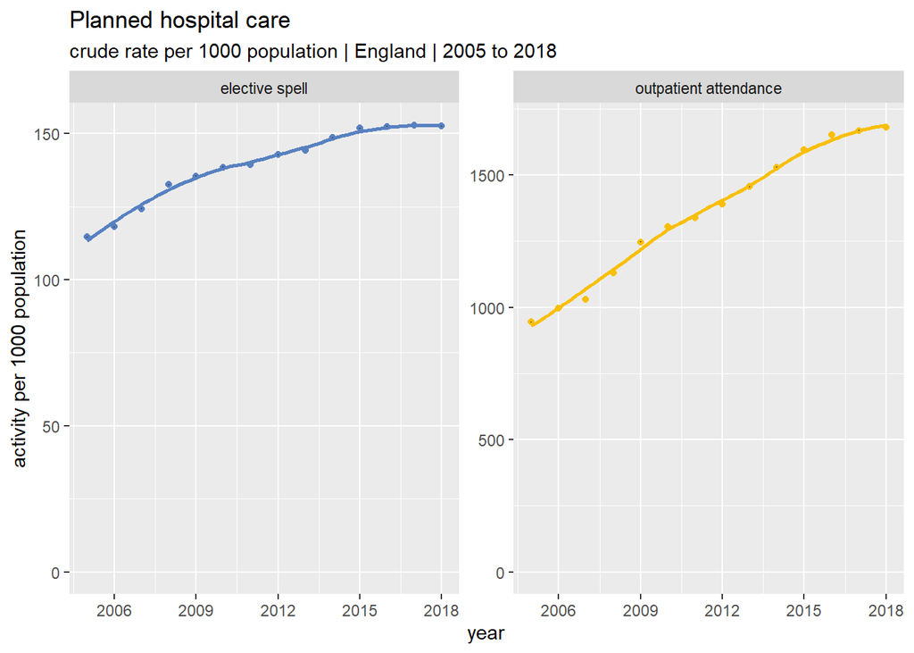

```r
actRates %>%
  filter(actType == 'ipElec' | actType == 'opAll') %>%
  filter(rateType == 'crude') %>%
  filter(STP20CD == 'all') %>%
  filter(imd2019Dec == 'all') %>%
  filter(icd10Chapter == 'all') %>%
  ggplot() +
  geom_smooth(aes(x = yr, y = rate*1000, colour = actTypeLabel),
              method = 'loess',
              se = FALSE) +
  geom_point(aes(x = yr, y = rate*1000, colour = actTypeLabel)) +
  geom_segment(aes(x = yr, xend = yr, y = lcl95*1000, yend = ucl95*1000),
               colour = '#2c2825') +
  scale_y_continuous(name = 'activity per 1000 population',
                     limits = c(0, NA_real_)) +
  scale_x_continuous(name = 'year', breaks = seq(2006, 2018, 3)) +
  scale_colour_manual(values = c('#5881c1', '#f9bf07')) +
  facet_wrap(~actTypeLabel, scales = 'free_y') +
  labs(title = 'Planned hospital care',
       subtitle = 'crude rate per 1000 population | England | 2005 to 2018') +
  theme(legend.position = 'none')
```

```r
actRateChanges <- actRates %>%
  filter(actType == 'ipElec' | actType == 'opAll') %>%
  filter(rateType == 'crude') %>%
  filter(STP20CD == 'all') %>%
  filter(imd2019Dec == 'all') %>%
  filter(icd10Chapter == 'all') %>%
  filter(yr == 2005 | yr == 2018) %>%
  select(yr, actType, rate) %>%
  pivot_wider(names_from = 'yr',
              values_from = 'rate',
              names_prefix = 'rate') %>%
  mutate(growth = (rate2018/rate2005) - 1) %>%
  mutate(growthPa = (rate2018 / rate2005) ^ (1/13) - 1)
```

In 2018, there were 152.5 elective spells and 1681 outpatient attendances per 1000 population in the England.

The level of planned hospital care increased considerably between 2005 and 2018. Rates of elective spells per head of population have increased by 33.1% between 2005 and 2018 (2.2% per annum), whilst outpatient attendances per head increased by 78.1% (4.5% per annum).

#### 3.2 Rates of planned hospital care by age and sex

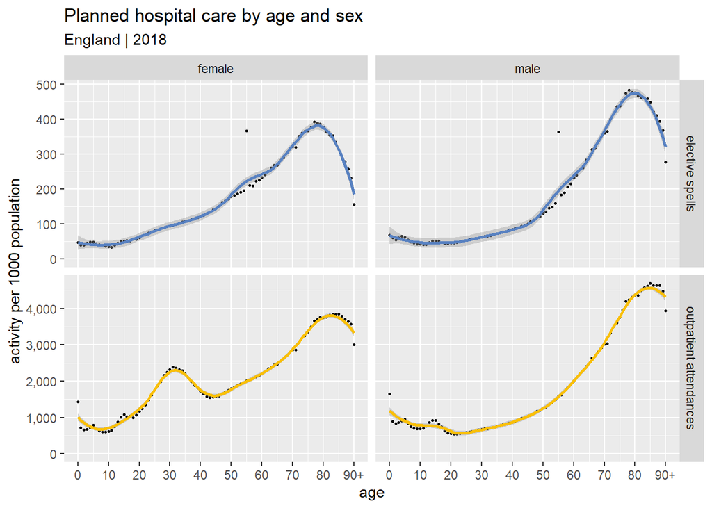

```r
IneqSecCareDsrInput %>%
  filter(yr == 2018) %>%
  #filter(age != 90) %>%
  group_by(age, sex) %>%
  summarise(ipElec = sum(ipElec, na.rm = TRUE),
            opAll = sum(opAll, na.rm = TRUE),
            pop = sum(pop, na.rm = TRUE)) %>%
  pivot_longer(cols = 3:4,
               names_to = 'actType',
               values_to = 'act') %>%
  mutate(actRate = act / pop) %>%
  mutate(sexLabel = if_else(sex == 1, 'male', 'female'),
         actTypeLabel = if_else(actType == 'ipElec', 'elective spells', 'outpatient attendances')) %>%
  ggplot() +
  geom_point(aes(x = age, y = 1000*actRate),
             size = 0.5) +
  geom_smooth(aes(x = age, y = 1000*actRate, colour = actTypeLabel),
              method = 'loess',
              formula = 'y ~ x',
              span = 0.3) +
  scale_y_continuous(name = 'activity per 1000 population',
                     limits = c(0, NA_real_),
                     labels = comma_format()) +
  scale_x_continuous(breaks = seq(0, 90, 10),
                     labels = c('0', '10', '20', '30', '40', '50', '60', '70', '80', '90+')) +
  scale_colour_manual(values = c('#5881c1', '#f9bf07')) +
  facet_grid(cols = vars(sexLabel),
             rows = vars(actTypeLabel),
             scale = 'free_y') +
  labs(title = 'Planned hospital care by age and sex',
      subtitle = 'England | 2018') +
  theme(legend.position = 'none')
```

Rates of planned hospital care rise slowly with age to age 50 and then more sharply to age 80, before declining. Obstetrics and gynaecology activity elevates outpatient rates for women aged 20-45. Rates of elective spells and outpatient attendances are higher in older men than in women of the same age. The bowel scope screening programme had a substantial impact on activity rates for men and women aged 55, but this screening programme was discontinued in January 2021.

#### 3.3 Rates of planned hospital care by ICD10 chapter

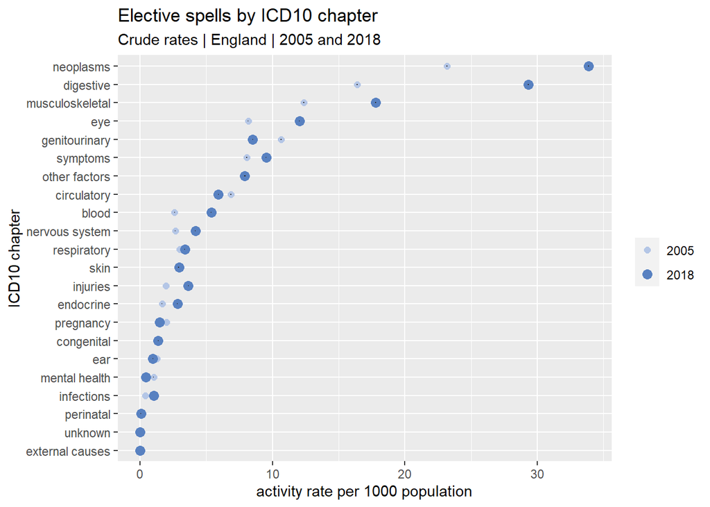

```r
actRates %>%
  filter(actType == 'ipElec') %>%
  filter(rateType == 'crude') %>%
  filter(STP20CD == 'all') %>%
  filter(imd2019Dec == 'all') %>%
  filter(icd10Chapter != 'all') %>%
  filter(yr == 2018 | yr == 2005) %>%
  mutate(icd10Label = case_when(icd10Chapter == 'AB' ~ 'infections',
                                icd10Chapter == 'CD04' ~ 'neoplasms',
                                icd10Chapter == 'D59' ~ 'blood',
                                icd10Chapter == 'E' ~ 'endocrine',
                                icd10Chapter == 'F' ~ 'mental health',
                                icd10Chapter == 'G' ~ 'nervous system',
                                icd10Chapter == 'H05' ~ 'eye',
                                icd10Chapter == 'H69' ~ 'ear',
                                icd10Chapter == 'I' ~ 'circulatory',
                                icd10Chapter == 'J' ~ 'respiratory',
                                icd10Chapter == 'K' ~ 'digestive',
                                icd10Chapter == 'L' ~ 'skin',
                                icd10Chapter == 'M' ~ 'musculoskeletal',
                                icd10Chapter == 'N' ~ 'genitourinary',
                                icd10Chapter == 'O' ~ 'pregnancy',
                                icd10Chapter == 'P' ~ 'perinatal',
                                icd10Chapter == 'Q' ~ 'congenital',
                                icd10Chapter == 'R' ~ 'symptoms',
                                icd10Chapter == 'ST' ~ 'injuries',
                                icd10Chapter == 'VWXY' ~ 'external causes',
                                icd10Chapter == 'Z' ~ 'other factors',
                                icd10Chapter == 'U' ~ 'unknown',
                                TRUE ~ 'check')) %>%
  ggplot() +
  geom_point(aes(y = reorder(icd10Label, rate), x = rate*1000,
                 colour = as.factor(yr),
                 size = as.factor(yr))) +
  geom_segment(aes(y = reorder(icd10Label, rate), yend = reorder(icd10Label, rate), x = lcl95*1000, xend = ucl95*1000),
               colour = '#2c2825') +
  scale_x_continuous(name = 'activity rate per 1000 population') +
  scale_y_discrete(name = 'ICD10 chapter') +
  scale_colour_manual(values = c('#b4c6e6', '#5881c1')) +
  scale_size_manual(values = c(2, 3)) +
  labs(title = 'Elective spells by ICD10 chapter',
      subtitle = 'Crude rates | England | 2005 and 2018') +
  theme(legend.title = element_blank())
```

Cancer, digestive system disorders and musculo-skeletal conditions were the most common driver of elective inpatient spells. Between 2005 and 2018, absolute growth was largest for disorders of the digestive system and for cancers. In relative terms, growth was greatest for infections, blood disorders and injuries. These differential growth rates are likely to be a product of differential changes in need, treatment options, treatment thresholds and capacity.

#### 3.4 Differences in rates of planned hospital care by deprivation

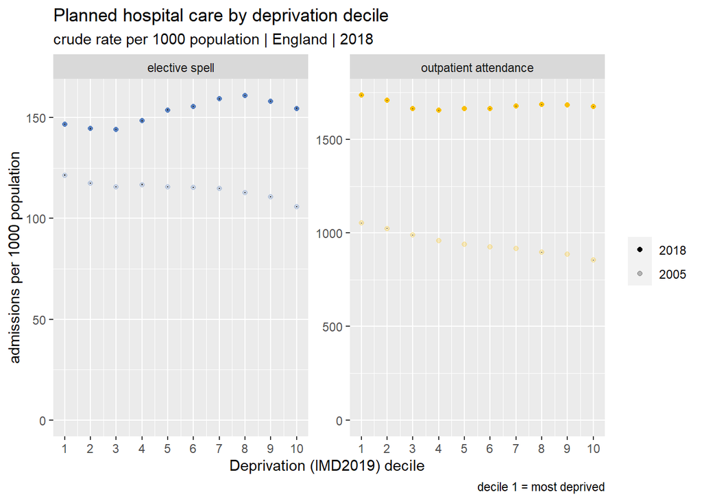

```r
actRates %>%
  filter(actType == 'ipElec' | actType == 'opAll') %>%
  filter(rateType == 'crude') %>%
  filter(STP20CD == 'all') %>%
  filter(imd2019Dec != 'all') %>%
  filter(icd10Chapter == 'all') %>%
  filter(yr == 2018 | yr == 2005) %>%
  mutate(yr = factor(yr, levels = c(2018, 2005))) %>%
  ggplot() +
  geom_point(aes(x = as.numeric(imd2019Dec), y = rate*1000, colour = actTypeLabel, alpha = yr))  +
  geom_segment(aes(x = as.numeric(imd2019Dec), xend = as.numeric(imd2019Dec), y = lcl95*1000, yend = ucl95*1000),
               colour = '#2c2825') +
  scale_y_continuous(name = 'admissions per 1000 population',
                     limits = c(0, NA_real_)) +
  scale_x_continuous(name = 'Deprivation (IMD2019) decile ', breaks = seq(1, 10, 1)) +
  scale_colour_manual(values = c('#5881c1', '#f9bf07')) +
  scale_alpha_manual(values = c(1, 0.25)) +
  facet_wrap(~actTypeLabel, scales = 'free_y') +
  labs(title = 'Planned hospital care by deprivation decile',
       subtitle = 'crude rate per 1000 population | England | 2018',
       caption = 'decile 1 = most deprived') +
  theme(legend.title = element_blank()) +
  guides(colour = FALSE)
```

In 2005, crude rates of elective spells favoured those living in the most deprived areas. By 2018 the gradient for elective spells had reversed such that crude rates were highest amongst the least deprived populations.

There is now no observable gradient in rates of outpatient attendances, although a gradient in favour of the most deprived areas was present in 2005.

#### 3.5 Changes in rates of planned hosptal care by deprivation

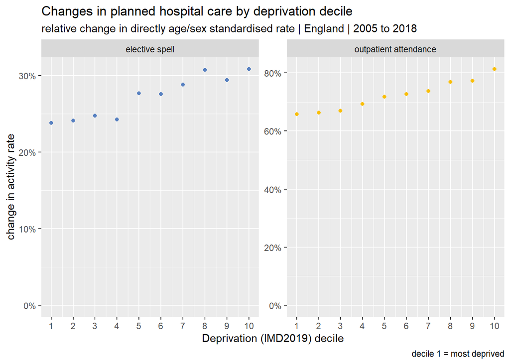

```r
actRates %>%
  filter(actType == 'ipElec' | actType == 'opAll') %>%
  filter(rateType == 'dsr') %>%
  filter(STP20CD == 'all') %>%
  filter(imd2019Dec != 'all') %>%
  filter(icd10Chapter == 'all') %>%
  filter(yr == 2018 | yr == 2005) %>%
  select(yr, imd2019Dec, actType, actTypeLabel, rateType, rate) %>%
  pivot_wider(names_from = yr, values_from = rate, names_prefix = 'rate') %>%
  mutate(absDiffRate = rate2018 - rate2005,
         relDiffRate = (rate2018 - rate2005) / rate2005) %>%
  ggplot() +
  geom_point(aes(x = as.numeric(imd2019Dec), y = relDiffRate, colour =actTypeLabel)) +
  scale_y_continuous(name = 'change in activity rate',
                     limits = c(0, NA_real_),
                     labels = percent_format()) +
  scale_x_continuous(name = 'Deprivation (IMD2019) decile', breaks = seq(1, 10, 1)) +
  scale_colour_manual(values = c('#5881c1', '#f9bf07')) +
  labs(title = 'Changes in planned hospital care by deprivation decile',
       subtitle = 'relative change in directly age/sex standardised rate | England | 2005 to 2018',
       caption = 'decile 1 = most deprived') +
  facet_wrap(~actTypeLabel, scales = 'free_y') +
  theme(legend.position = 'none')
```

After taking account of differential changes in the age/sex structure, rates of elective spells and outpatient attendances for those living in the most deprived areas have grown at a slower rate.

#### 3.7 Differences in rates of elective spells by deprivation and condition

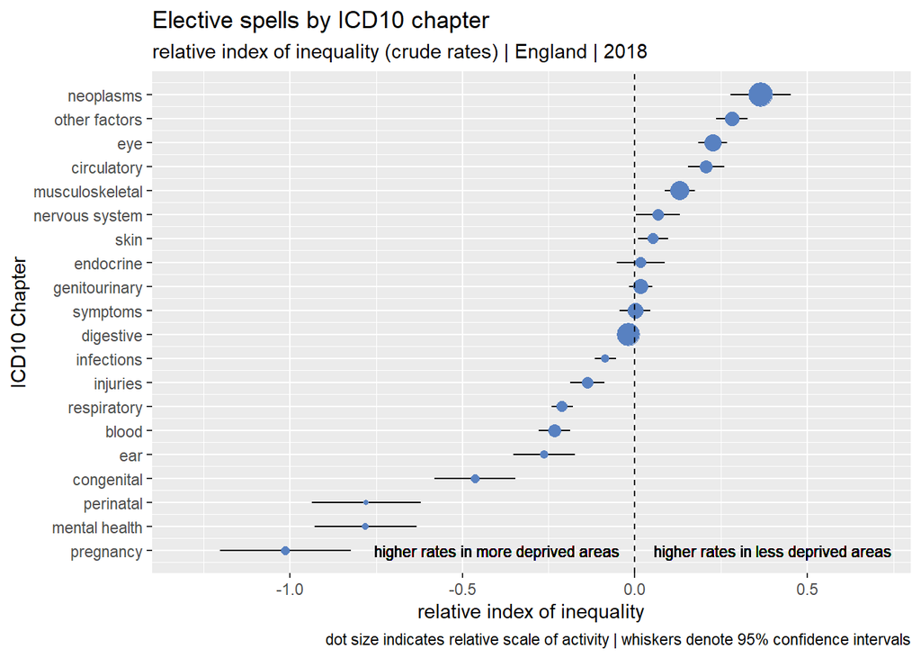

```r
# calculate sii by ICD10 chapter and for elective admissions

siiIcd10ResultsDf <- data.frame(icd10Label = character(),
                              rateType = character(),
                              pred1 = numeric(),
                              pred1se = numeric(),
                              pred10 = numeric(),
                              pred10se = numeric())



  for (j in c('infections', 'neoplasms', 'blood', 'endocrine', 'mental health',
              'nervous system', 'eye', 'ear', 'circulatory', 'respiratory',
              'digestive', 'skin', 'musculoskeletal', 'genitourinary', 'pregnancy',
              'perinatal', 'congenital', 'symptoms', 'injuries', 'external causes',
              'other factors', 'unknown'))
  {

    for (k in c('crude', 'dsr'))

    {

      modDf <- actRates %>%
        filter(rateType == k) %>%
        filter(icd10Label == j) %>%
        filter(imd2019Dec != 'all') %>%
        filter(icd10Chapter != 'all') %>%
        filter(actType == 'ipElec') %>%
        filter(yr == 2018) %>%
        mutate(imd2019Dec = as.numeric(imd2019Dec))

      mod <- lm(rate ~ imd2019Dec,
                data = modDf,
                weights = pop)

      modResults <- data.frame(icd10Label = j,
                               rateType = k,
                               pred1 = predict(mod)[1],
                               pred1se = predict(mod, se.fit = TRUE)$se.fit[1],
                               pred10 = predict(mod)[10],
                               pred10se = predict(mod, se.fit = TRUE)$se.fit[10])

      siiIcd10ResultsDf <- siiIcd10ResultsDf %>%
        bind_rows(modResults)

    }

  }


# calculate se of sii
####se(x/y) = sqrt( (x/y)^2 * (sex^2/x^2 + sey^2/y^2) ) --if x and y independent

siiIcd10ResultsDf <- siiIcd10ResultsDf %>%
  mutate(sii = pred10 - pred1) %>%
  mutate(siiSe = (pred1se ^ 2 + pred10se ^ 2) ^ 0.5) %>%
  mutate(siiLcl95 = sii - 1.96*siiSe,
         siiUcl95 = sii + 1.96*siiSe) %>%
  left_join(ipElecActIcd10Yr %>%
              filter(yr == 2018) %>%
              ungroup() %>%
              mutate(icd10Label = case_when(icd10Chapter == 'AB' ~ 'infections',
                                            icd10Chapter == 'CD04' ~ 'neoplasms',
                                            icd10Chapter == 'D59' ~ 'blood',
                                            icd10Chapter == 'E' ~ 'endocrine',
                                            icd10Chapter == 'F' ~ 'mental health',
                                            icd10Chapter == 'G' ~ 'nervous system',
                                            icd10Chapter == 'H05' ~ 'eye',
                                            icd10Chapter == 'H69' ~ 'ear',
                                            icd10Chapter == 'I' ~ 'circulatory',
                                            icd10Chapter == 'J' ~ 'respiratory',
                                            icd10Chapter == 'K' ~ 'digestive',
                                            icd10Chapter == 'L' ~ 'skin',
                                            icd10Chapter == 'M' ~ 'musculoskeletal',
                                            icd10Chapter == 'N' ~ 'genitourinary',
                                            icd10Chapter == 'O' ~ 'pregnancy',
                                            icd10Chapter == 'P' ~ 'perinatal',
                                            icd10Chapter == 'Q' ~ 'congenital',
                                            icd10Chapter == 'R' ~ 'symptoms',
                                            icd10Chapter == 'ST' ~ 'injuries',
                                            icd10Chapter == 'VWXY' ~ 'external causes',
                                            icd10Chapter == 'Z' ~ 'other factors',
                                            icd10Chapter == 'U' ~ 'unknown',
                                            TRUE ~ 'check')) %>%
              select(icd10Label, act),
            by = 'icd10Label')



riiIcd10ResultsDf <- siiIcd10ResultsDf %>%
  left_join(actRates %>%
              filter(yr == 2018) %>%
              filter(actType == 'ipElec') %>%
              filter(icd10Chapter != 'all') %>%
              filter(imd2019Dec == 'all') %>%
              filter(STP20CD == 'all') %>%
              mutate(icd10Label = case_when(icd10Chapter == 'AB' ~ 'infections',
                                            icd10Chapter == 'CD04' ~ 'neoplasms',
                                            icd10Chapter == 'D59' ~ 'blood',
                                            icd10Chapter == 'E' ~ 'endocrine',
                                            icd10Chapter == 'F' ~ 'mental health',
                                            icd10Chapter == 'G' ~ 'nervous system',
                                            icd10Chapter == 'H05' ~ 'eye',
                                            icd10Chapter == 'H69' ~ 'ear',
                                            icd10Chapter == 'I' ~ 'circulatory',
                                            icd10Chapter == 'J' ~ 'respiratory',
                                            icd10Chapter == 'K' ~ 'digestive',
                                            icd10Chapter == 'L' ~ 'skin',
                                            icd10Chapter == 'M' ~ 'musculoskeletal',
                                            icd10Chapter == 'N' ~ 'genitourinary',
                                            icd10Chapter == 'O' ~ 'pregnancy',
                                            icd10Chapter == 'P' ~ 'perinatal',
                                            icd10Chapter == 'Q' ~ 'congenital',
                                            icd10Chapter == 'R' ~ 'symptoms',
                                            icd10Chapter == 'ST' ~ 'injuries',
                                            icd10Chapter == 'VWXY' ~ 'external causes',
                                            icd10Chapter == 'Z' ~ 'other factors',
                                            icd10Chapter == 'U' ~ 'unknown',
                                            TRUE ~ 'check')) %>%
              select(icd10Label, rateType, globalRate = rate),
            by = c('icd10Label', 'rateType'))  %>%
  mutate(rii = sii / globalRate) %>%
  mutate(riiLcl95 = siiLcl95 / globalRate,
         riiUcl95 = siiUcl95 / globalRate) %>%
  arrange(rateType, rii) %>%
  mutate(odr = row_number())

riiIcd10ResultsDf %>%
  filter(rateType == 'crude') %>%
  filter(!is.na(sii)) %>%
  filter(act != 0) %>%
  ggplot() +
  geom_segment(aes(x = riiLcl95, xend = riiUcl95, y = odr, yend = odr), colour = 'black') +
  geom_point(aes(x = rii, y = odr, size = act), colour = '#5881c1') +
  geom_vline(aes(xintercept = 0), linetype = 'dashed') +
  geom_text(aes(x = -0.4, y = 1, label = 'higher rates in more deprived areas'), size = 3) +
  geom_text(aes(x = 0.4, y = 1, label = 'higher rates in less deprived areas'), size = 3) +
  scale_y_continuous(name = 'ICD10 Chapter',
                     breaks = riiIcd10ResultsDf$odr,
                     labels = riiIcd10ResultsDf$icd10Label) +
  scale_x_continuous(name = 'relative index of inequality',
                     limits = c(-1.3, 0.7)) +
  labs(title = 'Elective spells by ICD10 chapter',
       subtitle = 'relative index of inequality (crude rates) | England | 2018',
       caption = 'dot size indicates relative scale of activity | whiskers denote 95% confidence intervals') +
  theme(legend.position = 'none')
```

The relative index of inequality (RII) can be used to measure the direction and extent of any inequality in rates of healthcare use by people living in areas of differing levels of deprivation.

Rates of elective spells for most of the major causes of morbidity (including cancer, circulatory, ophthalmic, musculo-skeletal, nervous system and skin conditions) are skewed towards people living in the least deprived areas.

#### 3.8 Differences in rates of elective spells by deprivation and STP

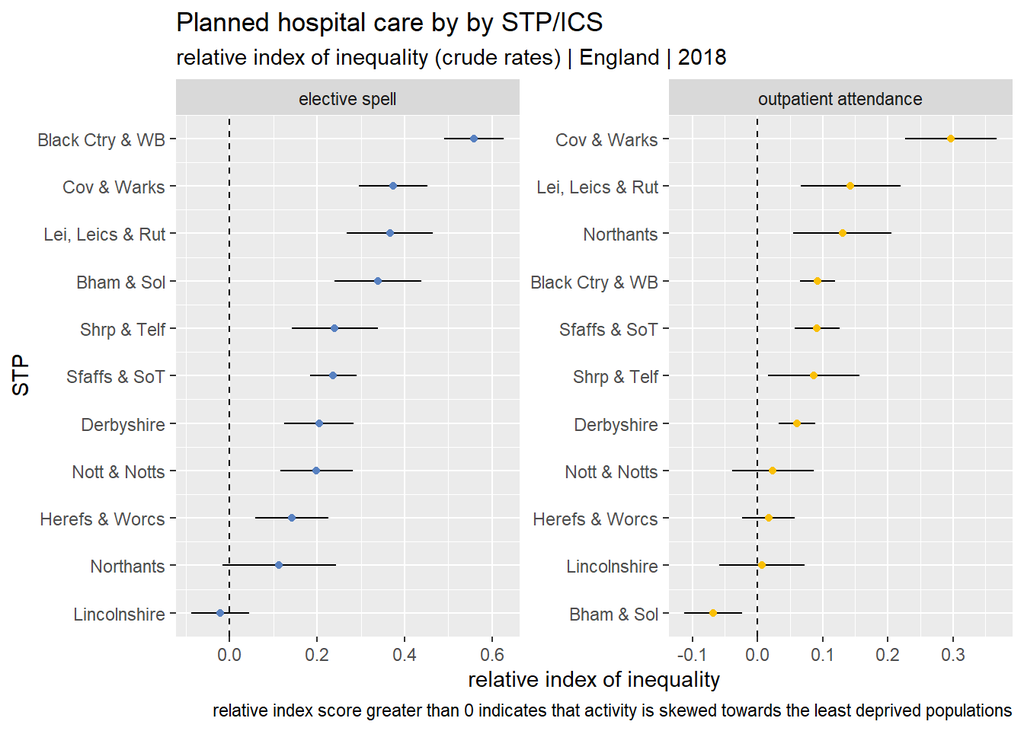

```r
# calculate sii by STP and for ipelec and opall

siiStpResultsDf <- data.frame(STP20ShNm = character(),
                           actTypeLabel = character(),
                           rateType = character(),
                           pred1 = numeric(),
                           pred1se = numeric(),
                           pred10 = numeric(),
                           pred10se = numeric())


for (i in c('elective spell', 'outpatient attendance'))

{

  for (j in c('Sfaffs & SoT', 'Shrp & Telf', 'Derbyshire', 'Lincolnshire',
              'Nott & Notts', 'Lei, Leics & Rut', 'Black Ctry & WB', 'Bham & Sol',
              'Cov & Warks', 'Herefs & Worcs', 'Northants'))
  {

    for (k in c('crude', 'dsr'))

    {

      modDf <- actRates %>%
        filter(actTypeLabel == i) %>%
        filter(rateType == k) %>%
        filter(STP20ShNm == j) %>%
        filter(imd2019Dec != 'all') %>%
        filter(icd10Chapter == 'all') %>%
        filter(yr == 2018) %>%
        mutate(imd2019Dec = as.numeric(imd2019Dec))

      mod <- lm(rate ~ imd2019Dec,
              data = modDf,
              weights = pop)

      modResults <- data.frame(STP20ShNm = j,
                             actTypeLabel = i,
                             rateType = k,
                             pred1 = predict(mod)[1],
                             pred1se = predict(mod, se.fit = TRUE)$se.fit[1],
                             pred10 = predict(mod)[10],
                             pred10se = predict(mod, se.fit = TRUE)$se.fit[10])

      siiStpResultsDf <- siiStpResultsDf %>%
        bind_rows(modResults)

    }

  }

}


# calculate se of sii

siiStpResultsDf <- siiStpResultsDf %>%
  mutate(sii = pred10 - pred1) %>%
  mutate(siiSe = ((pred10se ^ 2 + pred1se ^ 2) ^ 0.5)) %>%
  mutate(siiLcl95 = sii - 1.96*siiSe,
         siiUcl95 = sii + 1.96*siiSe)

riiStpResultsDf <- siiStpResultsDf %>%
  filter(rateType == 'crude') %>%
  left_join(actRates %>%
              filter(yr == 2018) %>%
              filter(actType == 'ipElec' | actType == 'opAll') %>%
              filter(icd10Chapter == 'all') %>%
              filter(imd2019Dec == 'all') %>%
              filter(STP20CD != 'all') %>%
              mutate(STP20ShNm = case_when(STP20CD == 'E54000007' ~ 'G Manc',
                                           STP20CD == 'E54000008' ~ 'Ches & Mrsy',
                                           STP20CD == 'E54000009' ~ 'S Yorks & Bass',
                                           STP20CD == 'E54000010' ~ 'Sfaffs & SoT',
                                           STP20CD == 'E54000011' ~ 'Shrp & Telf',
                                           STP20CD == 'E54000012' ~ 'Derbyshire',
                                           STP20CD == 'E54000013' ~ 'Lincolnshire',
                                           STP20CD == 'E54000014' ~ 'Nott & Notts',
                                           STP20CD == 'E54000015' ~ 'Lei, Leics & Rut',
                                           STP20CD == 'E54000016' ~ 'Black Ctry & WB',
                                           STP20CD == 'E54000017' ~ 'Bham & Sol',
                                           STP20CD == 'E54000018' ~ 'Cov & Warks',
                                           STP20CD == 'E54000019' ~ 'Herefs & Worcs',
                                           STP20CD == 'E54000020' ~ 'Northants',
                                           STP20CD == 'E54000021' ~ 'Cambs & Pet',
                                           STP20CD == 'E54000022' ~ 'Norf & Wav',
                                           STP20CD == 'E54000023' ~ 'Suff & NE Essex',
                                           STP20CD == 'E54000024' ~ 'Bedf, Lut & MK',
                                           STP20CD == 'E54000025' ~ 'Hets & W Essex',
                                           STP20CD == 'E54000026' ~ 'Mid & S Essex',
                                           STP20CD == 'E54000027' ~ 'NW London',
                                           STP20CD == 'E54000028' ~ 'N London',
                                           STP20CD == 'E54000029' ~ 'E London',
                                           STP20CD == 'E54000030' ~ 'SE London',
                                           STP20CD == 'E54000031' ~ 'SW London',
                                           STP20CD == 'E54000032' ~ 'Kent & Medway',
                                           STP20CD == 'E54000034' ~ 'Frimley',
                                           STP20CD == 'E54000036' ~ 'Cornwall & IoSc',
                                           STP20CD == 'E54000037' ~ 'Devon',
                                           STP20CD == 'E54000038' ~ 'Somerset',
                                           STP20CD == 'E54000039' ~ 'Bris, NE Sm & S Gl',
                                           STP20CD == 'E54000040' ~ 'Bth, NE Sm, Sw & Wlt',
                                           STP20CD == 'E54000041' ~ 'Dorset',
                                           STP20CD == 'E54000042' ~ 'Hamps & IoW',
                                           STP20CD == 'E54000043' ~ 'Gloucs',
                                           STP20CD == 'E54000044' ~ 'Bucks, Oxon & Brks W',
                                           STP20CD == 'E54000048' ~ 'Lancs & S Cumb',
                                           STP20CD == 'E54000050' ~ 'Cumb & NE',
                                           STP20CD == 'E54000051' ~ 'Humber, Cst & Vl',
                                           STP20CD == 'E54000052' ~ 'Surrey Hrtlds',
                                           STP20CD == 'E54000053' ~ 'Sussex & E Surr',
                                           STP20CD == 'E54000054' ~ 'W Yorks & Harr')) %>%
              mutate(actTypeLabel = case_when(actType == 'ipElec' ~ 'elective spell',
                                              actType == 'ipEmer' ~ 'emergency spell',
                                              actType == 'opAll' ~ 'outpatient attendance',
                                              TRUE ~ 'check')) %>%
              select(STP20ShNm, rateType, actTypeLabel, globalRate = rate),
            by = c('STP20ShNm', 'rateType', 'actTypeLabel'))  %>%
  mutate(rii = sii / globalRate) %>%
  mutate(riiLcl95 = siiLcl95 / globalRate,
         riiUcl95 = siiUcl95 / globalRate) %>%
  ungroup() %>%
  arrange(actTypeLabel, rii) %>%
  mutate(odr = row_number()) %>%
  group_by(actTypeLabel)

riiStpResultsDf %>%
  #filter(rateType == 'crude') %>%
  ggplot() +
  geom_segment(aes(x = riiLcl95, xend = riiUcl95, y = odr, yend = odr), colour = 'black') +
  geom_point(aes(x = rii, y = odr, colour = actTypeLabel)) +
  geom_vline(aes(xintercept = 0), linetype = 'dashed') +
  facet_wrap(~actTypeLabel, scales = 'free') +
  scale_y_continuous(name = 'STP',
                     breaks = riiStpResultsDf$odr,
                     labels = riiStpResultsDf$STP20ShNm) +
  scale_x_continuous(name = 'relative index of inequality') +
  scale_colour_manual(values = c('#5881c1', '#f9bf07')) +
  labs(title = 'Planned hospital care by by STP/ICS',
       subtitle = 'relative index of inequality (crude rates) | England | 2018',
       caption = 'relative index score greater than 0 indicates that activity is skewed towards the least deprived populations' )  +
  theme(legend.position = 'none')
```

In most STPs/ICSs, rates of elective spells and outpatient attendances are skewed towards people living in the least deprived areas.